# Appendix: Consistent long-distance foraging flights across years and seasons at colony level in a Neotropical bat

Published

July 17, 2024

# Note

This document contains the development of the Hidden Markov model set up for the simulation of bat nightly trips. This includes the code for the regularisation of trajectories

# Session set-up

**Setup**

```r
library(ctmm)
library(ggplot2)
library(sf)
library(suntools)
library(plyr)
library(ggspatial)
library(geosphere)
library(lubridate)
library(momentuHMM)
library(viridisLite)
library(terra)

proj.ll <- '+proj=longlat +datum=WGS84'
```

# Data import

## Cave locations

```r
cave.loc <- data.frame(
  cave=c('lagruta', 'ajcave', 'muddycave'),
  long=c(-82.271541, -82.274955, -82.264753),
  lat=c(9.396448, 9.440312, 9.387233)
)
```

## Land/sea mask

I will be using the administrative boundary data provided by GADM to derive a land/sea mask. FIrst, let’s import the administrative boundaries for Panama and Costa Rica and merge them:

```r
adm <- rbind(st_read('data/environmental/gadm41_PAN_shp/gadm41_PAN_0.shp', quiet=T),
             st_read('data/environmental/gadm41_CRI_shp/gadm41_CRI_0.shp', quiet=T))

coastline <- st_union(adm)
```

The next step sets up a grid with a resolution of 100m, and calculates for each grid cell the distance to the nearest land in km (i.e. distance to land for cells within the administrative boundary are 0). The resulting raster is then transformed using log(x+1) The distance calculation takes some time, so I will save the resulting raster for convenience.

```r
library(terra)

mask <- st_transform(coastline, st_crs(proj.utm))
mask <- rasterize(vect(mask), y=rast(extent=ext(c(50000, 750000, 750000, 1300000)), resolution=c(100,100)), values=1, background=0)

crs(mask) <- proj.utm
d2coast <- distance(mask, vect(st_transform(coastline, st_crs(proj.utm))))
d2coast <- log1p(d2coast/1000)

writeRaster(d2coast, filename='output/d2coast_100m.tif', filetype='GTiff')
```

## Tracking data

Importing the data with annotated behavior following from the initial HMM, and making some changes to naming/labelling:

```r
load('data/Phyllostomus2021-2022_HMMbehaviors.RData')

# rename caves
bats_behaviors$cave[bats_behaviors$cave=='LG'] <- 'lagruta'
bats_behaviors$cave[bats_behaviors$cave=='MT'] <- 'ajcave'

# remove columns that contain no data
bats_behaviors <- bats_behaviors[,apply(bats_behaviors, 2, function(x){any(!is.na(x))})]

# assign season
bats_behaviors$season <- ifelse(bats_behaviors$month %in% c('Aug', 'Dec'), 'wet', 'dry')

# assign "day" by calculating time of day relative to solar noon
p <- st_as_sf(bats_behaviors, coords=c('location_long', 'location_lat'), crs=st_crs(proj.ll))
noon <- solarnoon(p, bats_behaviors$timestamp, POSIXct.out=T)

# fractional hours after noon
bats_behaviors$tod <- as.numeric(difftime(bats_behaviors$timestamp, noon$time, units = 'h'))%%24

# split individual tracks into separate days
bats_behaviors <- ddply(bats_behaviors, 'individual_id', function(x){
  x$day <- c(0, cumsum(diff(x$tod)<0)) + 1
  return(x)
})
```

To be able to use spatial covariates and produce sensible simulations directly from the HMM, we need to reproject the entire data from long-lat to a metric coordinate reference system. Since momentuHMM can calculate step lengths for either long-lat or UTM, so we can use the respective UTM zone for Panama.

```r
# reprojecting everything (UTM zone 17N)
proj.utm <- '+proj=utm +zone=17 +ellps=GRS80 +units=m +no_defs +type=crs'
mask <- st_transform(coastline, st_crs(proj.utm))

p <- st_as_sf(bats_behaviors, coords=c('location_long', 'location_lat'), crs=st_crs(proj.ll))
p <- st_transform(p, st_crs(proj.utm))
bats_behaviors$x.utm <- st_coordinates(p)[,1]
bats_behaviors$y.utm <- st_coordinates(p)[,2]
```

### Regularisation

Over the years tracking data were collected with different settings, while some of the tracks have issues with not perfectly regular data. Slight irregularities are probably fine, but for the HMM it will be necessary to derive a dataset with at least near-regular observations. Large irregularities can cause issues as step lengths to increase/decrease with longer/shorter observation intervals. As the HMM will have to account for these observations, they can have a serious impact on the resulting distributions describing the observation parameters for the different states.

We will use the correlated random walk models implemented in the **momentuHMM**-package (via the package **crawl**). In my experience, the mean estimates of single-state crawl models estimated for tracks capturing widely different modes of movement (e.g. resting behaviour and short shuttling flights between food tree and feeding roost) don’t always look great yet tend to still produce reasonable interpolations of the tracks.

Let’s first have a look at sampling intervals before regularisation to determine what would be a good interval to choose for the interpolation:

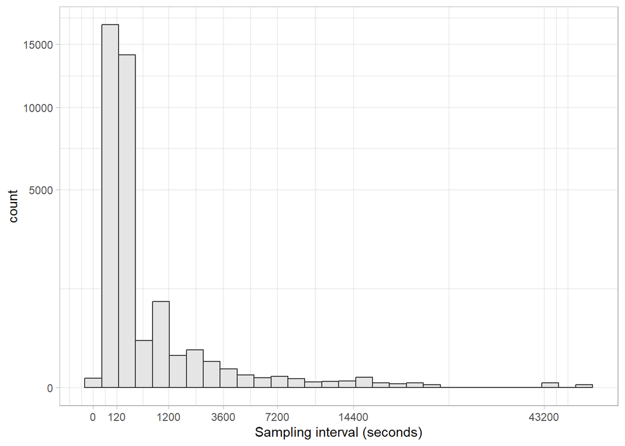

```r
## check sampling intervals
check.dt.before <- ddply(bats_behaviors, 'ID', function(x){
  data.frame(dt=diff(as.numeric(x$timestamp)))
})

ggplot(check.dt.before, aes(x=dt)) +
  geom_histogram(fill='grey90', colour='grey20') +
  scale_y_sqrt() + scale_x_sqrt(breaks=c(0,120,1200,3600,7200,14400,43200)) +
  labs(x='Sampling interval (seconds)') +
  theme_light()
```

The most common sampling interval was at around 120 seconds, which would make this a good interval for interpolating the tracks. Let’s fit a CRW model using crawl and interpolate tracks accordingly. As this step takes quite some time, I will save the output for convenience:

```r
bats.reg <- crawlWrap(bats_behaviors, timeStep=120, coord=c('x.utm', 'y.utm'), Time.name='timestamp')

save(bats.reg, file='240411_bats_regularised_crawl.RData')
```

### Prepare data for HMM

The steps included here are meant to set up the data for the HMM, which includes annotation with time of day, distance to land, as well as the distance and angle of locations to the respective cave of the individual.

```r
# prepare cave locations for angle calculation
p.caves <- st_as_sf(cave.loc, coords=c('long', 'lat'), crs=st_crs(proj.ll))
p.caves <- st_transform(p.caves, st_crs(proj.utm))
caves <- as.matrix(st_coordinates(p.caves))
dimnames(caves)[[1]] <- cave.loc$cave

# drop previously computed step ang angle columns to avoid conflicts with prepData()-function
bats.reg$crwPredict <- bats.reg$crwPredict[-which(names(bats.reg$crwPredict) %in% c('step', 'angle'))]

bats.reg$crwPredict <- ddply(bats.reg$crwPredict, 'ID', function(x){
  # calculate time of day relative to solar noon
  p <- st_as_sf(x, coords=c('mu.x', 'mu.y'), crs=st_crs(proj.utm))
  noon <- solarnoon(p, x$timestamp, POSIXct.out=T)
  x$tod <- as.numeric(difftime(x$timestamp, noon$time, units = 'h'))%%24

  # annotate locations with distance to land
  x$d2coast <- extract(d2coast, vect(p))$layer

  # assign cave
  x$cave <- unique(x$cave[!is.na(x$cave)])
  return(x)
})

# convert data to momentuHMM format
bats <- prepData(bats.reg,
                 # coordNames = c('x.utm', 'y.utm'),
                 # covNames=c('cave'),
                 type = 'UTM',
                 centers = caves)#,
                 # spatialCovs = list(mask=raster(as.factor(mask))))

# make new angle covariate choosing the angle to the respective cave for each individual
bats$cave.angle <- unlist(lapply(1:nrow(bats), function(j){
  keep <- ifelse(bats$cave[j]=='lagruta', bats$lagruta.angle[j],
                 ifelse(bats$cave[j]=='ajcave', bats$ajcave.angle[j], bats$muddycave.angle[j]))
}))

# make new distance covariate choosing the angle to the respective cave for each individual
bats$cave.dist <- unlist(lapply(1:nrow(bats), function(j){
  keep <- ifelse(bats$cave[j]=='lagruta', bats$lagruta.dist[j],
                 ifelse(bats$cave[j]=='ajcave', bats$ajcave.dist[j], bats$muddycave.dist[j]))
}))

# # some more preparatory steps
# set steps exceeding what would be expected at a speed of 40 m/s to NA
bats$step[bats$step>((120*40))] <- NA
```

# Hidden Markov models

## Simple model for parametrisation

We will start with a simple model as these tend to be easier to parametrise. This model will be characterised by:

- 3 states: foraging movements, outbound commutes (cave -> foraging), inbound commutes (foraging -> cave)
- 1 covariate on the transition probability matrix: time of day, as circular covariate
- 2 data streams derived from observations: step length (in m) and angle to cave (in radians)
- step and angle distribution as well as starting parameters (for step length) are based on first HMM

```r
# time of day as covariate on the transition probability matrix
tpm.formula <- ~cosinor(tod, 24)

# fit simple model with 3 states and starting
mod.smpl <- fitHMM(data=bats,
                   nbStates=3, # number of states
                   dist=list(step='gamma', cave.angle='wrpcauchy'), # distributions for observations
                   estAngleMean=list(cave.angle=TRUE), # estimate mean angle for angle to cave?
                   Par=list(step=c(0.07,1.15,1.40, # starting parameters
                                   0.1,0.5,0.75),
                           cave.angle=c(0, pi, 0,
                                   0.3,0.7,0.7)),
                 formula=tpm.formula, # formula for the transition probability matrix
                 stateNames=c('foraging','outbound','inbound')) # names for movement states
```

## Adding a distance to land as covariate on the transition probability matrix:

The only spatial covariate we only really need is the land/sea mask, and we will tell the model in advance that it is impossible to switch to the foraging state when not above land. I will further constrain the transition probability matrix so it becomes impossible to switch from outbound to inbound commute directly (and vice versa); i.e. bats have to forage in between outbound and inbound commute

```r
# extend formula on tpm
tpm.formula <- ~state1(d2coast) + cosinor(tod, 24)

# fix transitions so constrain transitions to foraging above water
# fix transitions
fix.beta <- matrix(c(NA,NA, NA,-100, NA,-100,
                     # NA,NA, NA,NA,   NA,NA,
                     rep(NA, 12),
                     NA,NA, -100,-100, -100,-100), nrow=4,byrow=T)

#################################################
## model

mod.mask <- fitHMM(data=bats,
                 nbStates=3,
                 dist=list(step='gamma', cave.angle='wrpcauchy'),
                 estAngleMean=list(cave.angle=TRUE),
                 Par=list(step=c(0.07,1.15,1.40,
                                   0.1,0.5,0.75),
                          cave.angle=c(pi, pi, 0,
                                 0.3,0.7,0.7)),
                 formula=tpm.formula,
                 fixPar=list(beta=fix.beta),
                 stateNames=c('foraging','outbound','inbound'))
```

## Rewrite existing model as biased correlated random walk model for commuting behaviour

With this prior information from the simple model, we can can re-write the commuting states as biased correlated random walks. We will also fix the sign of the bias for the two commuting states so that outbound commutes are pushed away from the cave (negative bias), and inbound commutes are pulled towards the cave (positive bias). In this model, we are further adding and interaction term for distance to land.

```r
#################################################
## angle formula + fixpar

angle.formula <- ~ state2(cave.angle) + state3(cave.angle)
fix.angle <- c(-1,1,NA,NA,NA)

#################################################
## formula on tpm + fixpar

tpm.formula <- ~d2coast + d2coast:I(d2coast>0) + cosinor(tod, 24)
fix.beta <- matrix(c(NA,NA, NA,-100, NA,-100,
                     # NA,NA, NA,NA,   NA,NA,
                     rep(NA, 24)), ncol=6,byrow=T)

#################################################
## formula on state distribution

bats$tod.frac <- bats$tod * pi/24
delta.formula <- ~cos(tod.frac) + sin(tod.frac)# same as cosinor(tod), but needed to be specified as the cosinor function does not work here

#################################################
## model

mod.bcrw.unknown <- fitHMM(data=bats,
                 nbStates=3,
                 dist=list(step='gamma', angle='wrpcauchy'),
                 estAngleMean=list(angle=TRUE),
                 circularAngleMean=list(angle=0),
                 Par=list(step=c(0.07,1.15,1.40,
                                   0.1,0.5,0.75)*1000,
                         angle=c(pi, 0,
                                 0.3,0.7,0.7)),
                 DM=list(angle=list(mean=angle.formula, concentration=~1)),
                 formula=tpm.formula,
                 # knownStates=knownstates,
                 fixPar=list(beta=fix.beta, angle=fix.angle),
                 stateNames=c('foraging','outbound','inbound'))
```

## Separate models for wet and dry season

Now that we have successfully established the final structure for the HMM, we can fit separate models for wet and dry season to allow for potential differences in movement behaviour and dynamics (state-switching) to carry over to the simulations.

Dry season:

```r
bats$season <- unlist(lapply(bats$ID, function(id){
  unique(bats$season[!is.na(bats$season) & bats$ID==id])
}))

# model for dry season
mod.bcrw.dry <- fitHMM(data=bats[bats$season=='dry',],
                 nbStates=3,
                 dist=list(step='gamma', angle='wrpcauchy'),
                 estAngleMean=list(angle=TRUE),
                 circularAngleMean=list(angle=0),
                 Par=list(step=c(0.07,1.15,1.40,
                                   0.1,0.5,0.75)*1000,
                         angle=c(pi, 0,
                                 0.3,0.7,0.7)),
                 DM=list(angle=list(mean=angle.formula, concentration=~1)),
                 formula=tpm.formula,
                 fixPar=list(beta=fix.beta, angle=fix.angle),
                 stateNames=c('foraging','outbound','inbound'))
```

```
Fitting HMM with 3 states and 2 data streams
```

```
 step ~ gamma(mean=~1, sd=~1)
```

```
 angle ~ wrpcauchy(mean=~state2(cave.angle) + state3(cave.angle), concentration=~1)
```

```
 Transition probability matrix formula: ~d2coast + d2coast:I(d2coast > 0) + cosinor(tod, 24)
```

```
 Initial distribution formula: ~1
```

```
DONE
```

```
Decoding state sequence... DONE
```

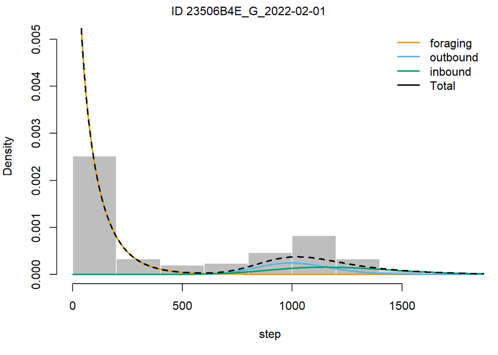

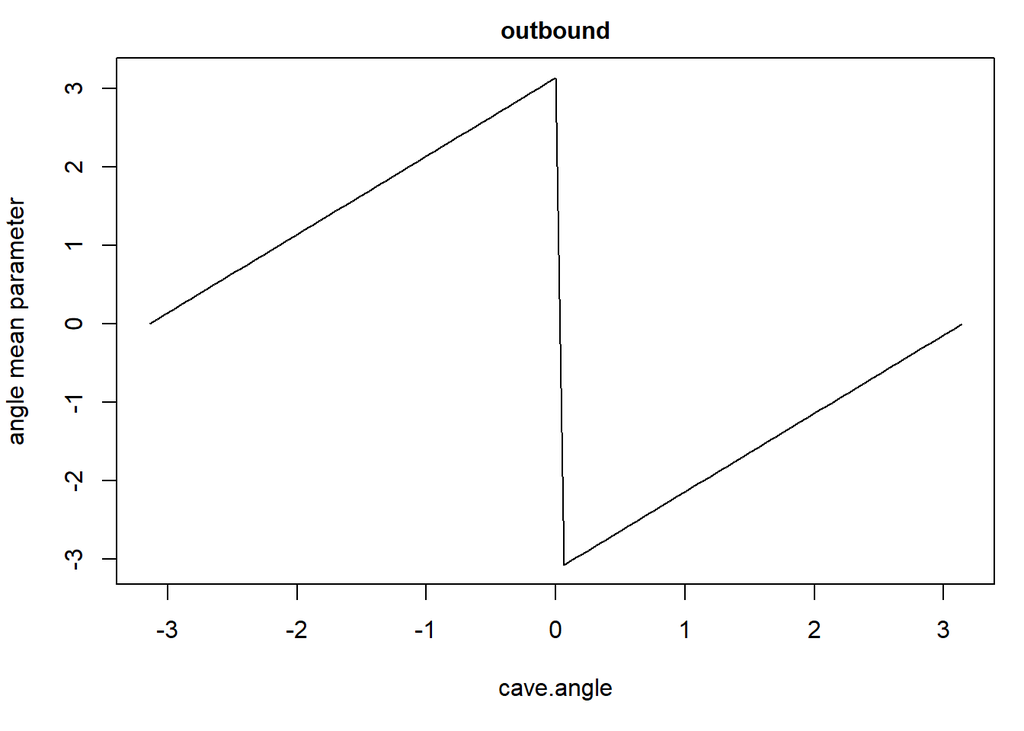

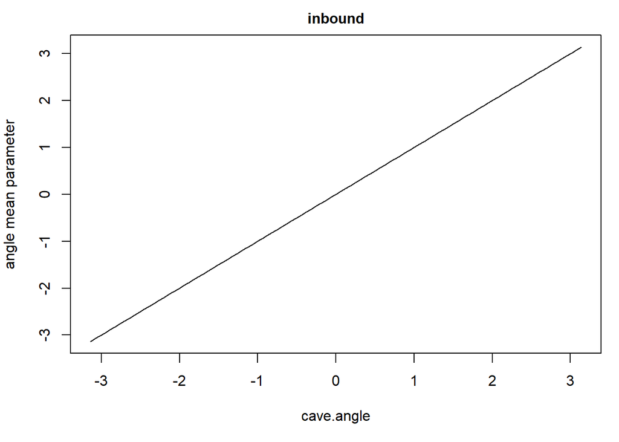

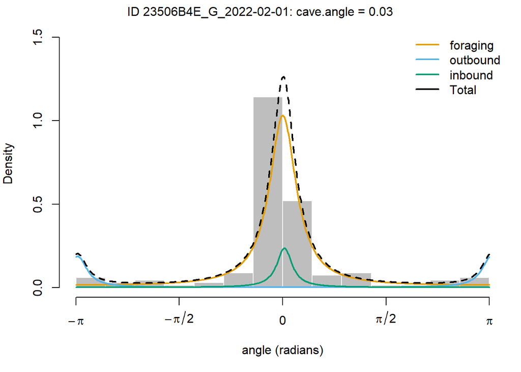

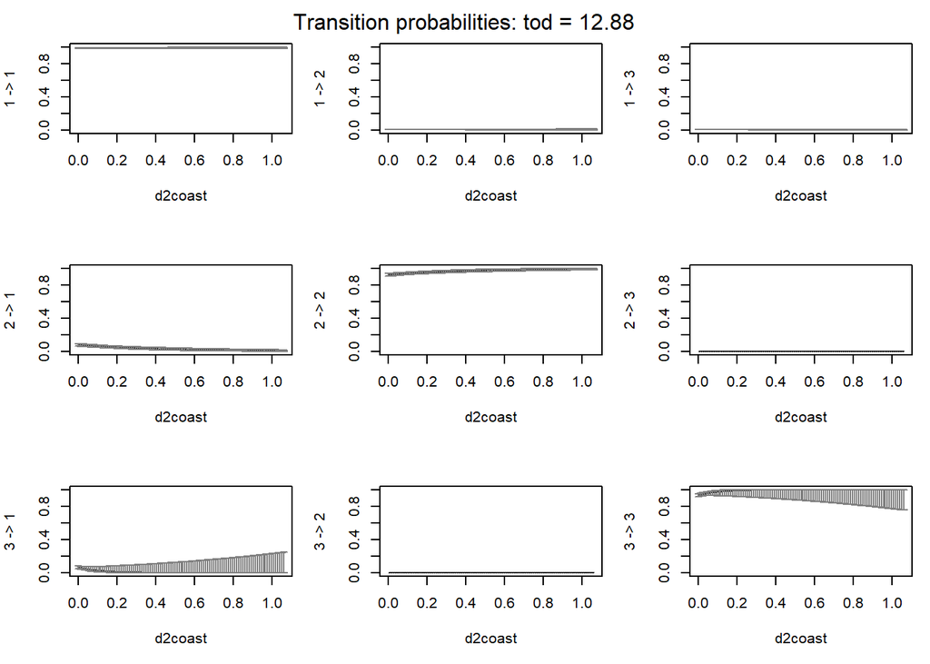

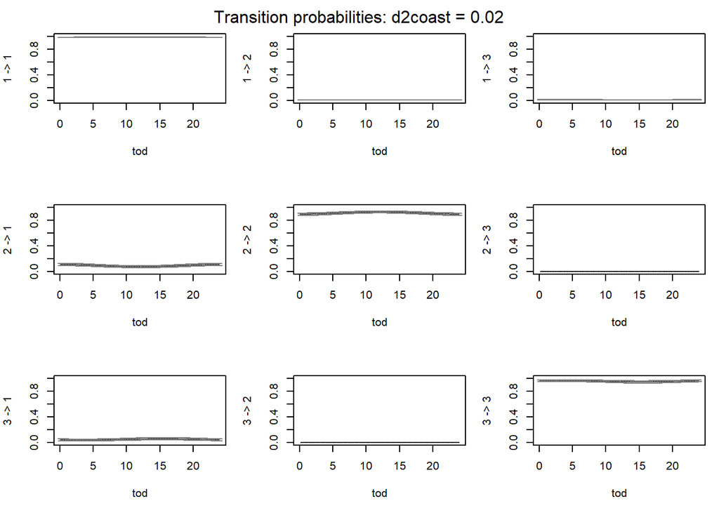

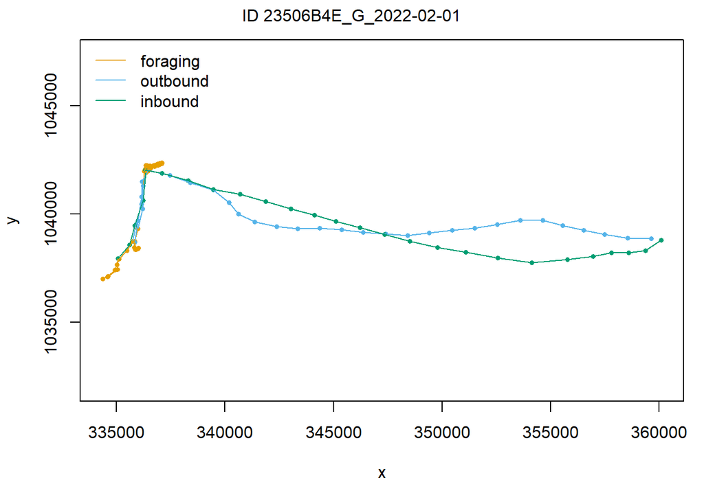

```r
plot(mod.bcrw.dry, plotTracks=T, animals=4, ask=F, plotCI=T)
```

```
Computing pseudo-residuals...
```

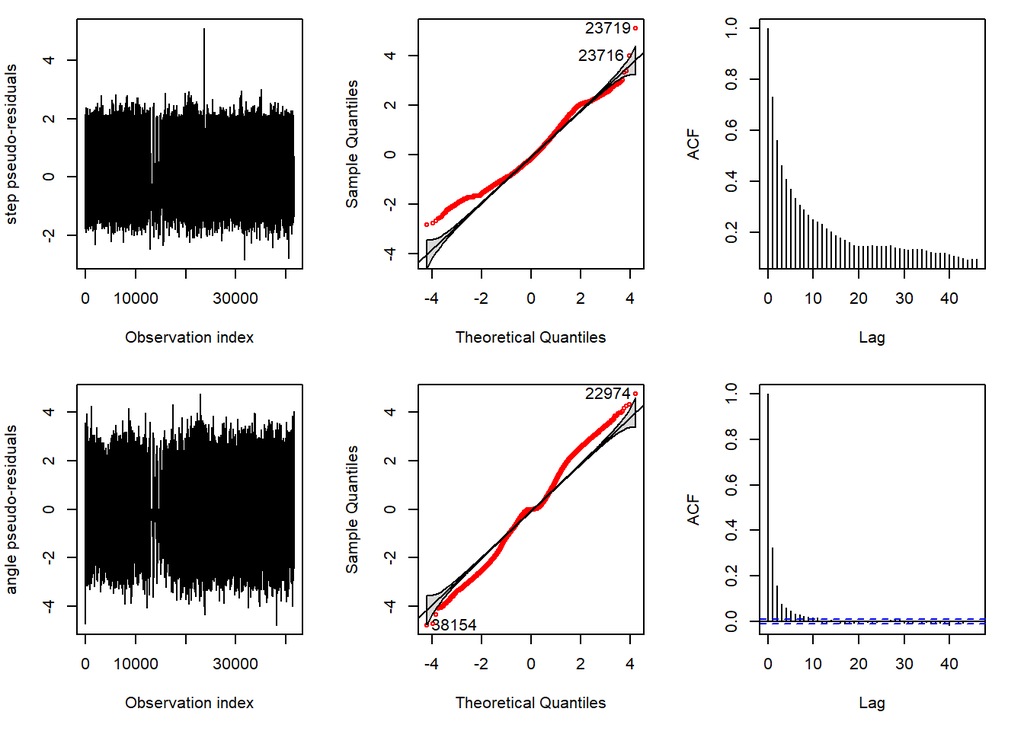

```r
plotPR(mod.bcrw.dry)
```

Wet season:

```r
# model for wet season
mod.bcrw.wet <- fitHMM(data=bats[bats$season=='wet',],
                 nbStates=3,
                 dist=list(step='gamma', angle='wrpcauchy'),
                 estAngleMean=list(angle=TRUE),
                 circularAngleMean=list(angle=0),
                 Par=list(step=c(0.07,1.15,1.40,
                                   0.1,0.5,0.75)*1000,
                         angle=c(pi, 0,
                                 0.3,0.7,0.7)),
                 DM=list(angle=list(mean=angle.formula, concentration=~1)),
                 formula=tpm.formula,
                 fixPar=list(beta=fix.beta, angle=fix.angle),
                 stateNames=c('foraging','outbound','inbound'))
```

```
Fitting HMM with 3 states and 2 data streams
```

```
 step ~ gamma(mean=~1, sd=~1)
```

```
 angle ~ wrpcauchy(mean=~state2(cave.angle) + state3(cave.angle), concentration=~1)
```

```
 Transition probability matrix formula: ~d2coast + d2coast:I(d2coast > 0) + cosinor(tod, 24)
```

```
 Initial distribution formula: ~1
```

```
DONE
```

```
Decoding state sequence... DONE
```

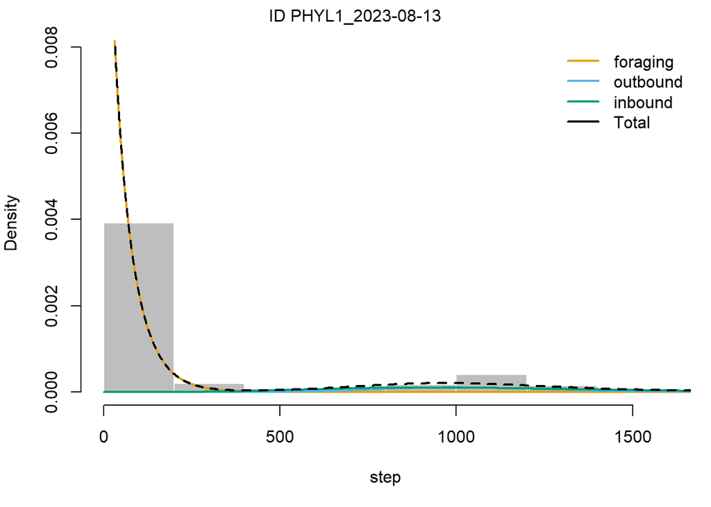

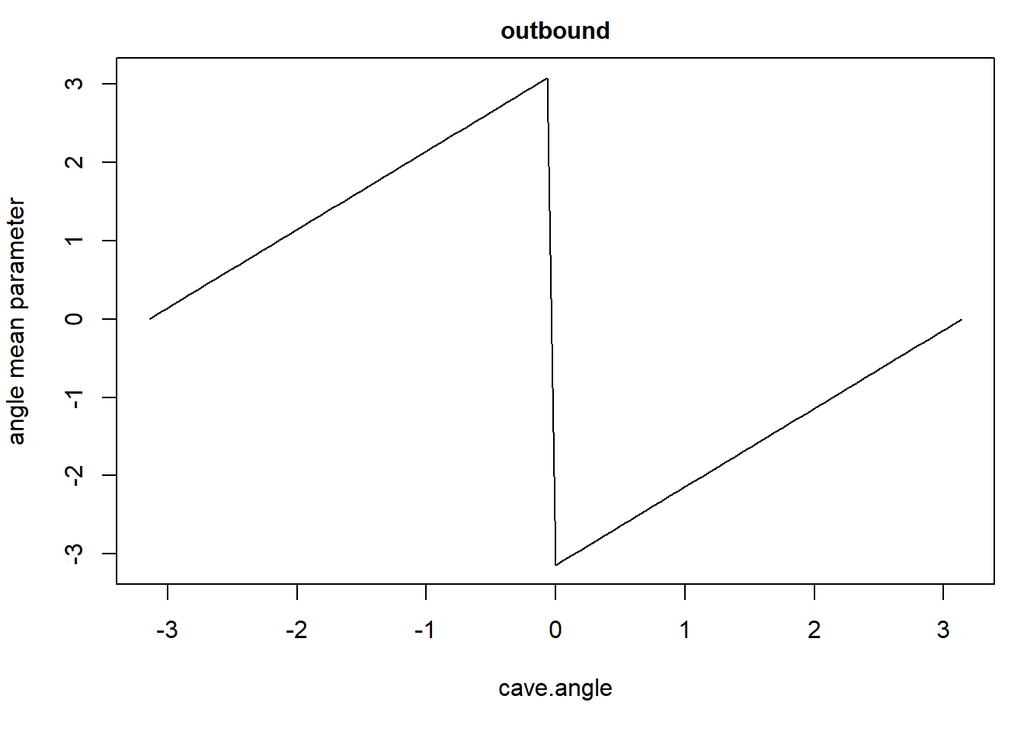

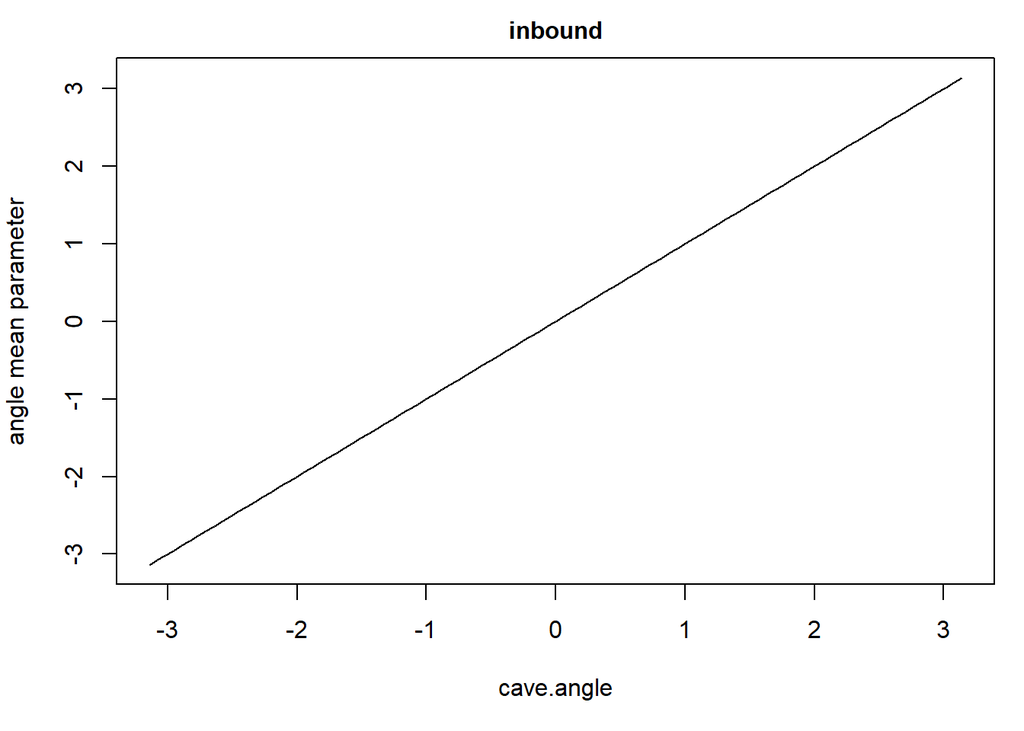

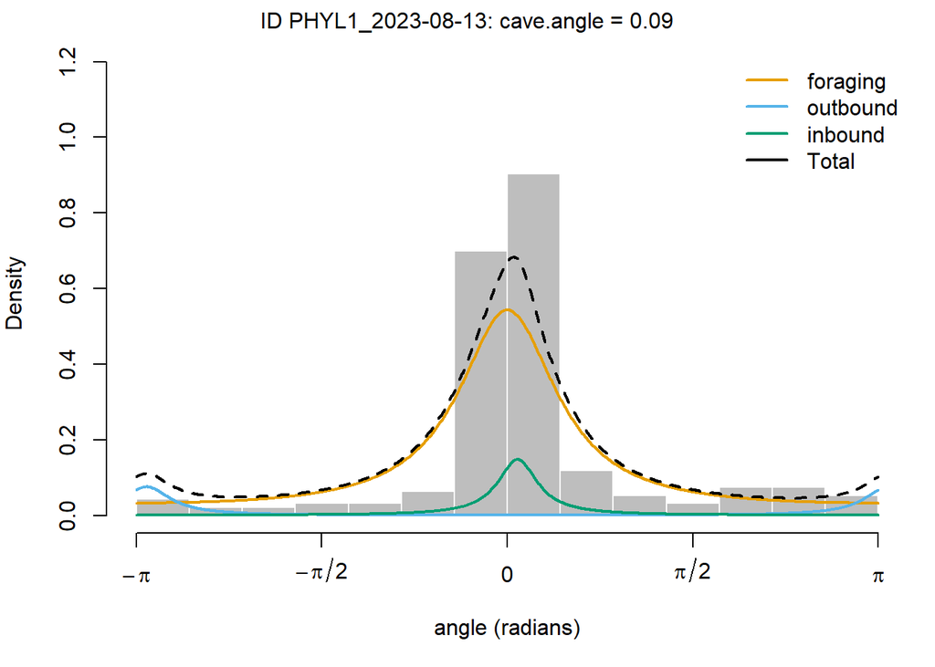

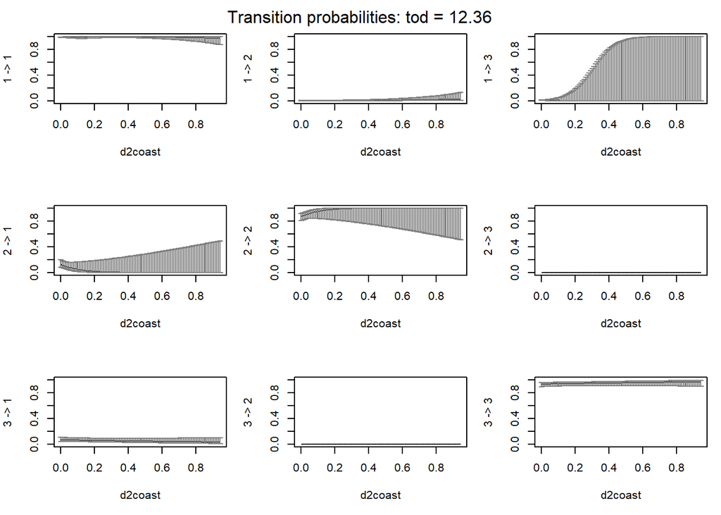

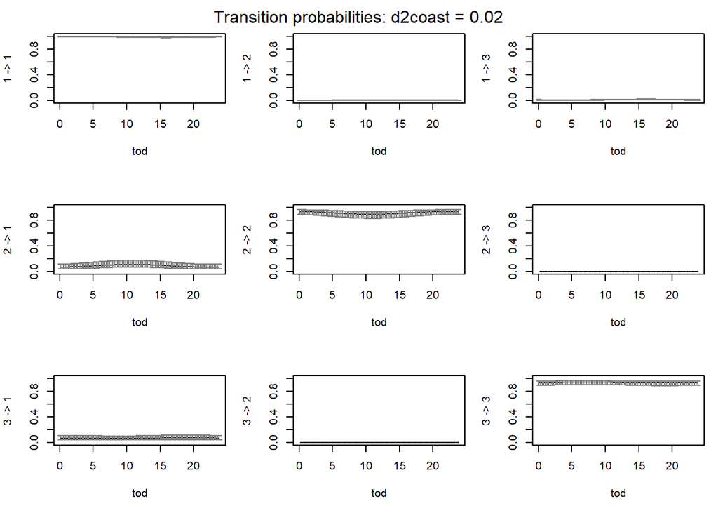

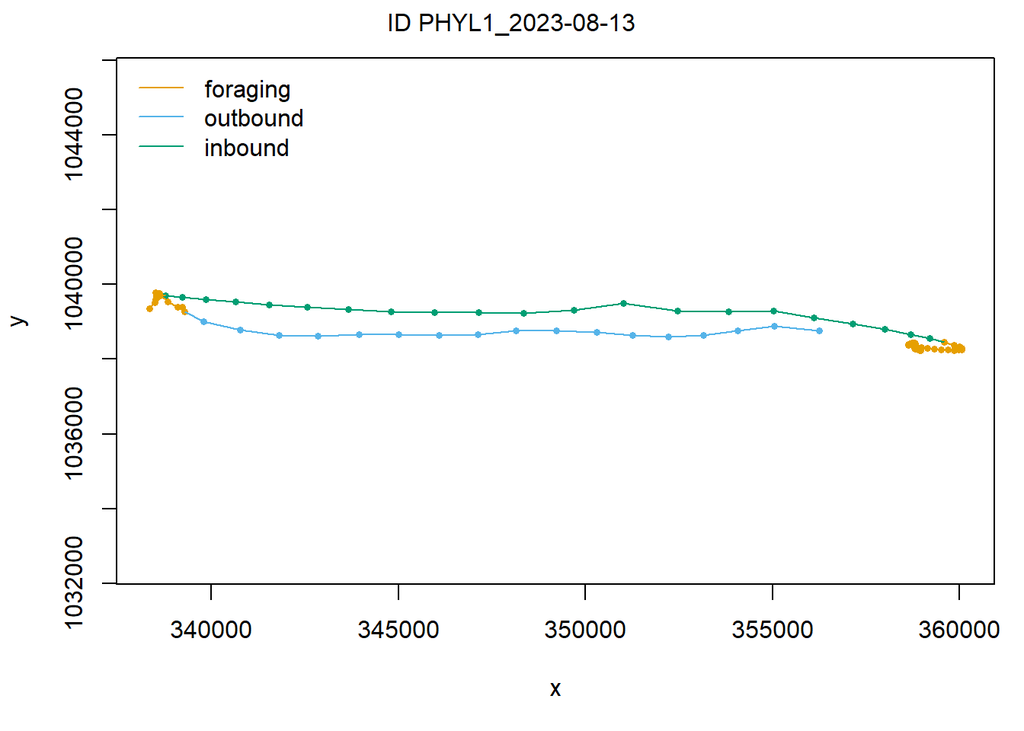

```r
plot(mod.bcrw.wet, plotTracks=T, animals=7, ask=F, plotCI=T)
```

```
Computing pseudo-residuals...
```

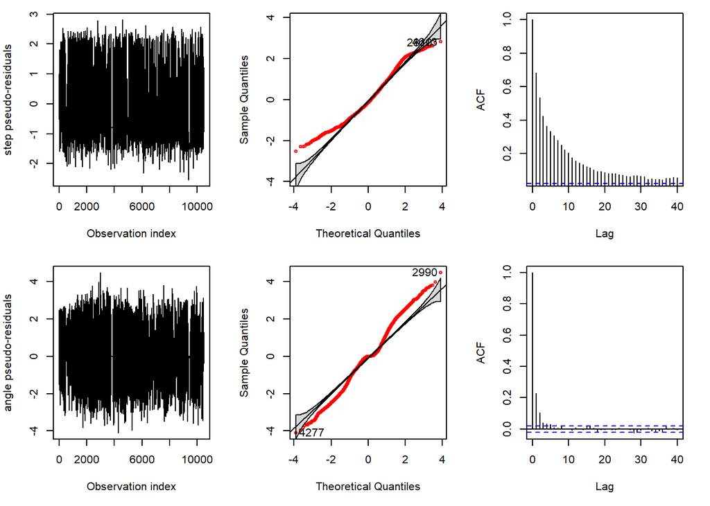

```r
plotPR(mod.bcrw.wet)
```

```r
# save models for convenience
save(mod.bcrw.wet, mod.bcrw.dry, file='240716_mod_bcrw_by_season.RData')
```

# Simulations

## Covariates for simulation

Since we included covariates in the HMMs, we can take these into account for the simulations as well.

### Time of day

Set up time series to allow simulations to take time of day into account Day was chosen randomly.

```r
# prepare time of day for simulation
ts <- seq.POSIXt(as.POSIXct('2023-02-24 00:00:00', tz='UTC'), as.POSIXct('2023-02-24 12:00:00', tz='UTC'), by=120)
p <- st_as_sf(cave.loc[1,], coords=c('long', 'lat'), crs=st_crs(proj.ll))
noon <- solarnoon(p, ts, POSIXct.out=T)
tod <- data.frame(tod=as.numeric(difftime(ts, noon$time, units = 'h'))%%24)
```

### Distance to land

No need to prepare anything as we already have the raster ready to go. When determining the extent for the original distance to land calculations, I made sure it would be of sufficient large with respect to spatial extent.

## Simulating bat trips

The **momentuHMM**-package comes with a tool for simulating time series from fitted HMMs. This allows users to see whether the model meaningfully captures the observed behaviour, but can also be useful in studies like this to explore how well the observations reflect our biological model of bat foraging trips.

For each colony and season, we will simulate $N_{i,j}\times3$ trips, with $N_i$ representing the number of observed bat-nights for colony $i$ during season $j$. We decided to simulate more trips as simulated trips will radiate out from the respective starting location (cave), and not all simulations will “hit” land. Simulating three times as many trips as observed trips should give us a similar sample size for observed and simulated foraging locations.

### Colony 1

```r
# use cave location as starting point for the simulation
cave <- matrix(as.vector(caves[1,]), ncol=2, byrow=T, dimnames=list('cave', c('x', 'y')))

# run 181 x 3 simulations for la gruta, dry season
lg.dry <- simData(nbAnimals=181*3,
                model=mod.bcrw.dry,
                states=T,
                spatialCovs=list(d2coast=raster(d2coast)),
                covs=tod,
                initialPosition=as.vector(caves[1,]),
                centers=cave,
                obsPerAnimal = c(104,203))

lg.dry$cave <- 'lagruta'
lg.dry$season <- 'dry'

# run 38x3 simulations for la gruta, wet season
lg.wet <- simData(nbAnimals=38*3,
                model=mod.bcrw.wet,
                states=T,
                spatialCovs=list(d2coast=raster(d2coast)),
                covs=tod,
                initialPosition=as.vector(caves[1,]),
                centers=cave,
                obsPerAnimal = c(104,203))

lg.wet$cave <- 'lagruta'
lg.wet$season <- 'wet'

lg <- rbind(lg.dry, lg.wet)
lg$type <- 'simulation'
rm(list=c('lg.dry', 'lg.wet'))
```

What do these simulations look like? Note that the trips that are not headed towards land never switch to foraging behaviour and just keep going. This behaviour of the simulation is intended, and a consequence of constraints on state-switching as defined in the model: the distance to land covariate ensures that simulations can only switch to foraging behaviour *above land*, whereas the constraints on state-switching means the simulations cannot switch from outbound to inbound commute directly.

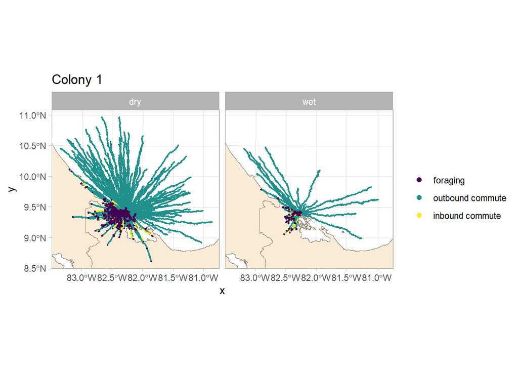

Figure shows simulations for colony 1 for dry and wet season.

```r
ggplot(simu[simu$cave=='lagruta',]) +
  geom_sf(data=st_transform(adm, st_crs(proj.utm)), fill='antiquewhite', colour='antiquewhite4', linewidth=0.2) +
  xlim(range(simu$x)) + ylim(range(simu$y)) +
  geom_path(aes(x=x, y=y, group=ID)) +
  geom_point(aes(x=x, y=y, colour=factor(states, labels=c('foraging', 'outbound commute', 'inbound commute'))), size=0.3) +
  geom_point(data=simu[simu$cave=='lagruta' & simu$states==1,], aes(x=x, y=y, colour=factor(states, labels=c('foraging'))), size=0.3) +
  scale_colour_viridis_d(name='') +
  theme_light() +
  guides(colour=guide_legend(override.aes = list(size=2))) +
  labs(title='Colony 1') +
  facet_wrap(~season, ncol=2)
```

### Colony 2

```r
# define cave as starting point
cave <- matrix(as.vector(caves[2,]), ncol=2, byrow=T, dimnames=list('cave', c('x', 'y')))

# run 121x3 simulations for colony 2, dry season
aj.dry <- simData(nbAnimals=121*3,
                model=mod.bcrw.dry,
                states=T,
                spatialCovs=list(d2coast=raster(d2coast)),
                covs=tod,
                initialPosition=as.vector(caves[1,]),
                centers=cave,
                obsPerAnimal = c(104,203))

aj.dry$cave <- 'ajcave'
aj.dry$season <- 'dry'

# run 38x3 simulations for colony 2, wet season
aj.wet <- simData(nbAnimals=38*3,
                model=mod.bcrw.wet,
                states=T,
                spatialCovs=list(d2coast=raster(d2coast)),
                covs=tod,
                initialPosition=as.vector(caves[1,]),
                centers=cave,
                obsPerAnimal = c(104,203))

aj.wet$cave <- 'ajcave'
aj.wet$season <- 'wet'

aj <- rbind(aj.dry, aj.wet)
aj$type <- 'simulation'
rm(list=c('aj.dry', 'aj.wet'))
```

### Colony 3

```r
# define cave as starting point
cave <- matrix(as.vector(caves[3,]), ncol=2, byrow=T, dimnames=list('cave', c('x', 'y')))

# run 46x3 simulations for colony 3, dry season
muddy <- simData(nbAnimals=46*3,
                model=mod.bcrw.dry,
                states=T,
                spatialCovs=list(d2coast=raster(d2coast)),
                covs=tod,
                initialPosition=as.vector(caves[1,]),
                centers=cave,
                obsPerAnimal = c(104,203))

muddy$cave <- 'muddycave'
muddy$season <- 'dry'
muddy$type <- 'simulation'
```

Save simulations to file:

```r
simu <- do.call('rbind', list(lg, aj, muddy))

save(simu, file='output/240418_simulations_all.RData')
```

# Extract observed and simulated foraging locations

## Prepare data

First location of a subsequent segment considered as foraging. I’ll be using Camila’s classification for the actual observations, and of course the states provided by the simulation. This can be more than one location per individual and night as individuals can use multiple locations.

```r
# extract foraging locations from original HMM
foraging.observed <- ddply(bats_behaviors, c('cave', 'season', 'ID'), function(x){
  x$seg <- c(0, cumsum(diff(as.numeric(factor(x$behav)))!=0)) + 1
  if(!any(x$behav=='foraging')){return(NULL)}
  new <- ddply(x[x$behav=='foraging',], 'seg', function(y){
    dur <- abs(diff(range(as.numeric(y$timestamp))))
    return(data.frame(long=y$location_long[1], lat=y$location_lat[1], duration=dur, individual=unique(y$individual_id)))
  })
  return(new[,-1])
})

foraging.observed$type <- 'observed'

# only keep segments with duration > 0
foraging.observed <- foraging.observed[foraging.observed$duration>0,]

# calculate angle & distance to cave
foraging.observed <- ddply(foraging.observed, c('cave', 'season', 'ID'), function(x){
  x$d2cave <- distGeo(x[,c('long', 'lat')], cave.loc[cave.loc$cave==unique(x$cave),2:3])/1000
  x$a2cave <- bearing(cave.loc[cave.loc$cave==unique(x$cave),2:3], x[,c('long', 'lat')])
  return(x)
})

###################################################################################################
# repeat for simulated foraging locations

foraging.simulated <- ddply(simu, c('cave', 'season', 'ID'), function(x){
  x$seg <- c(0, cumsum(diff(x$states)!=0)) + 1
  if(!any(x$states=='1')){return(NULL)}
  new <- ddply(x[x$states=='1',], 'seg', function(y){
    dur <- (nrow(y)*120)-120
    return(data.frame(long=y$x[1], lat=y$y[1], duration=dur, individual=paste(unique(y$cave), unique(y$season), sprintf('%.3d', unique(as.numeric(y$ID))), sep='-')))
  })
  return(new[,-1])
})

foraging.simulated$type <- 'simulated'

# only keep segments with duration > 0
foraging.simulated <- foraging.simulated[foraging.simulated$duration>0,]

# reproject to long-lat
p <- st_as_sf(foraging.simulated, coords=c('long', 'lat'), crs=st_crs(proj.utm))
p <- st_transform(p, st_crs(proj.ll))
foraging.simulated$long <- st_coordinates(p)[,1]
foraging.simulated$lat <- st_coordinates(p)[,2]

# calculate angle & distance to cave
foraging.simulated <- ddply(foraging.simulated, c('cave', 'season', 'ID'), function(x){
  x$d2cave <- distGeo(x[,c('long', 'lat')], cave.loc[cave.loc$cave==unique(x$cave),2:3])/1000
  x$a2cave <- bearing(cave.loc[cave.loc$cave==unique(x$cave),2:3], x[,c('long', 'lat')])
  return(x)
})

# combine observed & simulated

foraging <- rbind(foraging.observed, foraging.simulated)
```

Which foraging locations did the simulated bats “use”?

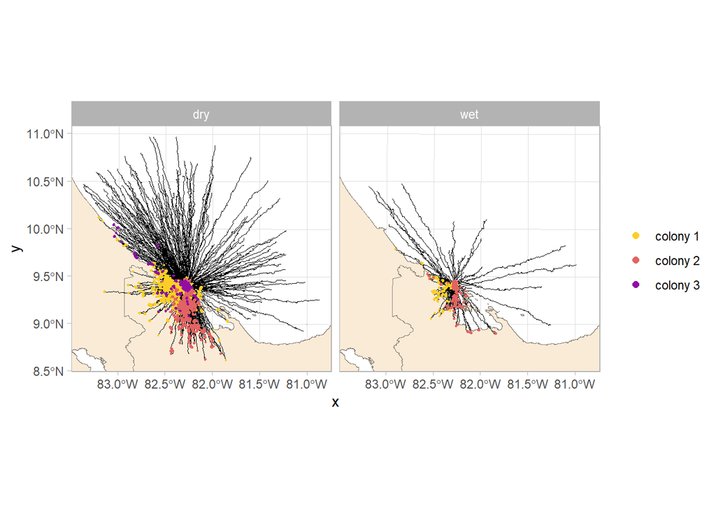

```r
ggplot(simu) +
  geom_sf(data=st_transform(adm, st_crs(proj.utm)), fill='antiquewhite', colour='antiquewhite4', linewidth=0.2) +
  xlim(range(simu$x)) + ylim(range(simu$y)) +
  geom_path(aes(x=x, y=y, group=paste(cave, season, ID, sep='-')), linewidth=0.1) +
  # geom_point(data=simu[simu$states==1,], aes(x=x, y=y, colour=factor(states, labels=c('foraging', 'outbound commute', 'inbound commute'))), size=0.3) +
  geom_point(data=simu[simu$states==1,], aes(x=x, y=y, colour=factor(cave, levels=c('lagruta', 'ajcave', 'muddycave'), labels=paste('colony', 1:3))), size=0.3) +
  scale_colour_viridis_d(name='', option='C', begin=0.3, end=0.9, direction=-1) +
  theme_light() +
  guides(colour=guide_legend(override.aes = list(size=2))) +
  facet_wrap(~season, ncol=2)
```

## Visualisation: Observed and simulated foraging locations

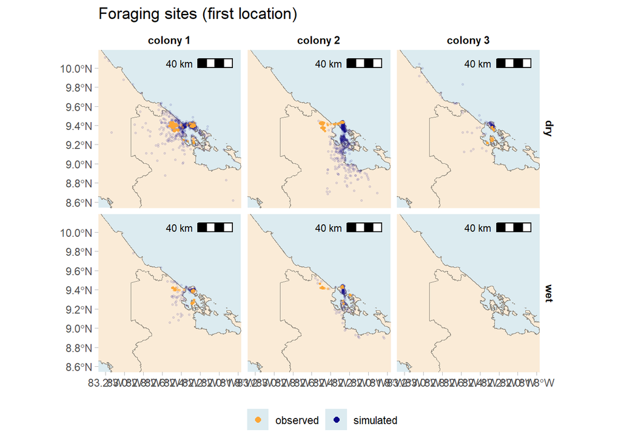

```r
ggplot() +
  geom_sf(data=adm, fill='antiquewhite', colour='antiquewhite4', linewidth=0.2) +
  xlim(range(foraging$long)) + ylim(range(foraging$lat)) +
  theme_light() +
  theme(axis.title=element_blank(),
        panel.grid=element_blank(),
        plot.background = element_rect(fill = "white", color = NA),
        panel.background = element_rect(fill = '#dcebf0', color = NA),
        legend.background = element_rect(fill = "white", color = NA), ##f5f5f2
        panel.border = element_blank()) +
  annotation_scale(location = "tr", line_width = 1) +
  labs(x='Longitude', y='Latitude') +
  geom_point(data=foraging[foraging$type=='simulated',], aes(x=long, y=lat, colour=type), alpha=0.1, size=0.5) +
  geom_point(data=foraging[foraging$type=='observed',], aes(x=long, y=lat, colour=type), alpha=.5, size=0.5) +
  scale_colour_viridis_d(end=0.8, option='C', name='', direction=-1) +
  facet_grid(season~factor(cave, levels=c('lagruta', 'ajcave', 'muddycave'), labels=paste('colony', 1:3))) +
  labs(title='Foraging sites (first location)') +
  theme(strip.background = element_rect(fill='white'), strip.text=element_text(colour='black', face='bold')) +
  theme(legend.position='bottom') +
  guides(colour=guide_legend(override.aes = list(size=2, alpha=1)))
```

```r
# ggsave(filename='240418_locations_obs_vs_sim.png', width=200, height=120, unit='mm')
```

### Visualisation: Foraging locations + time spent

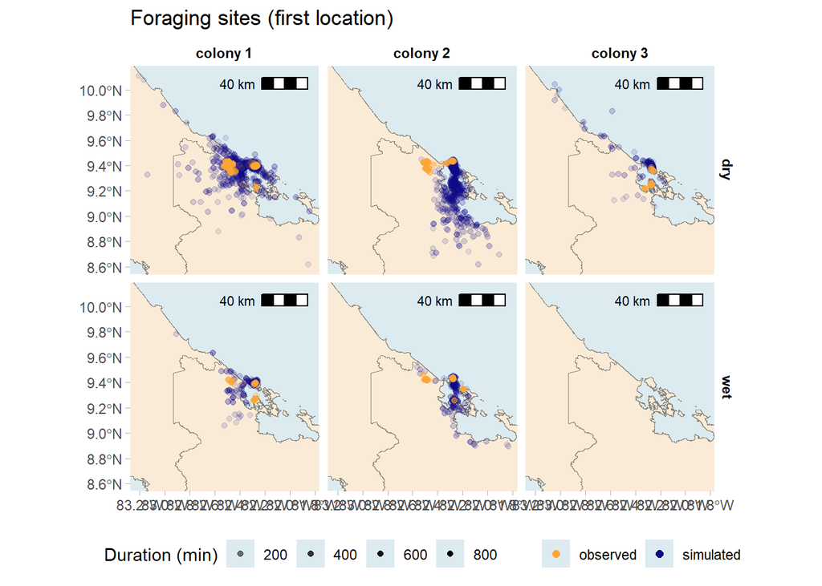

```r
ggplot() +
  geom_sf(data=adm, fill='antiquewhite', colour='antiquewhite4', linewidth=0.2) +
  xlim(range(foraging$long)) + ylim(range(foraging$lat)) +
  theme_light() +
  theme(axis.title=element_blank(),
        panel.grid=element_blank(),
        plot.background = element_rect(fill = "white", color = NA),
        panel.background = element_rect(fill = '#dcebf0', color = NA),
        legend.background = element_rect(fill = "white", color = NA), ##f5f5f2
        panel.border = element_blank()) +
  annotation_scale(location = "tr", line_width = 1) +
  labs(x='Longitude', y='Latitude') +
  scale_alpha(name='Duration (min)') +
  geom_point(data=foraging[foraging$type=='simulated',], aes(x=long, y=lat, colour=type, alpha=duration/60)) +
  geom_point(data=foraging[foraging$type=='observed',], aes(x=long, y=lat, colour=type, alpha=duration/60)) +
  scale_colour_viridis_d(end=0.8, option='C', name='', direction=-1) +
  facet_grid(season~factor(cave, levels=c('lagruta', 'ajcave', 'muddycave'), labels=paste('colony', 1:3))) +
  labs(title='Foraging sites (first location)') +
  theme(strip.background = element_rect(fill='white'), strip.text=element_text(colour='black', face='bold')) +
  theme(legend.position='bottom') +
  guides(colour=guide_legend(override.aes = list(size=2, alpha=1)))
```

### Distance and angle to foraging locations

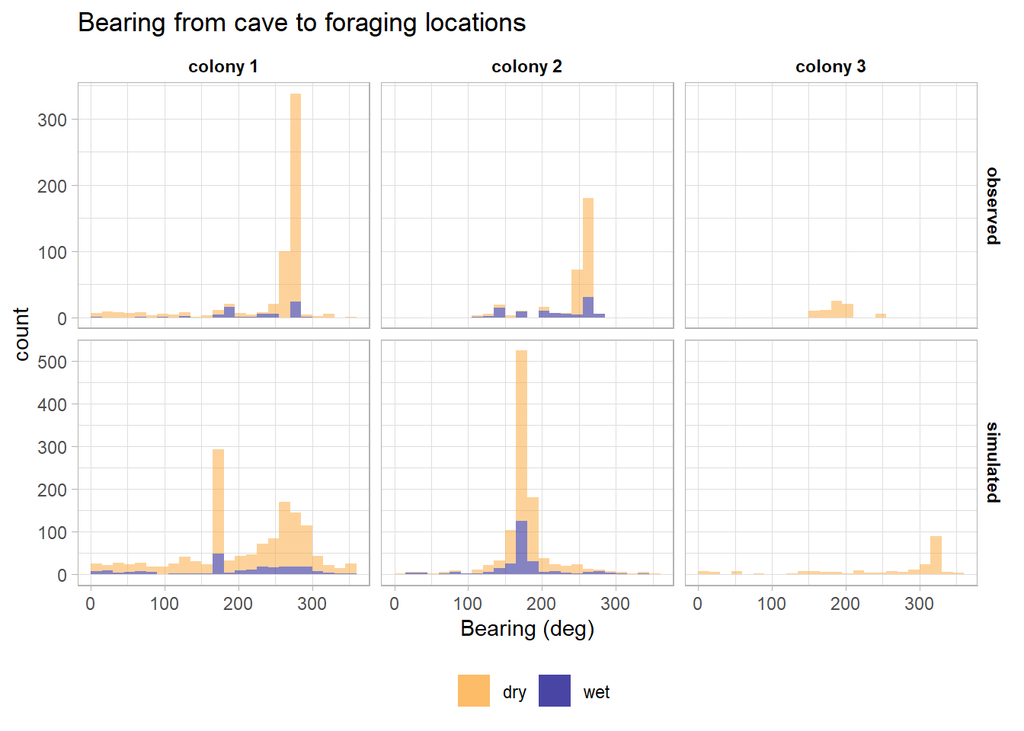

```r
ggplot() +
  theme_light() +
  labs(x='Bearing (deg)') +
  geom_histogram(data=foraging[foraging$type=='simulated',], aes(x=(a2cave+360)%%360, fill=season), alpha=0.5, breaks=seq(0,360,15)) +
  geom_histogram(data=foraging[foraging$type=='observed',], aes(x=(a2cave+360)%%360, fill=season), alpha=0.5, breaks=seq(0,360,15)) +
  scale_fill_viridis_d(end=0.8, option='C', name='', direction=-1) +
  facet_grid(type~factor(cave, levels=c('lagruta', 'ajcave', 'muddycave'), labels=paste('colony', 1:3)), scales='free_y') +
  theme(legend.position='bottom') +
  labs(title='Bearing from cave to foraging locations') +
  theme(strip.background = element_rect(fill='white'), strip.text=element_text(colour='black', face='bold')) +
  guides(colour=guide_legend(override.aes = list(size=2, alpha=1)))
```

```r
# ggsave(filename='240717_bearing_obs_vs_sim.png', width=200, height=120, unit='mm')
```

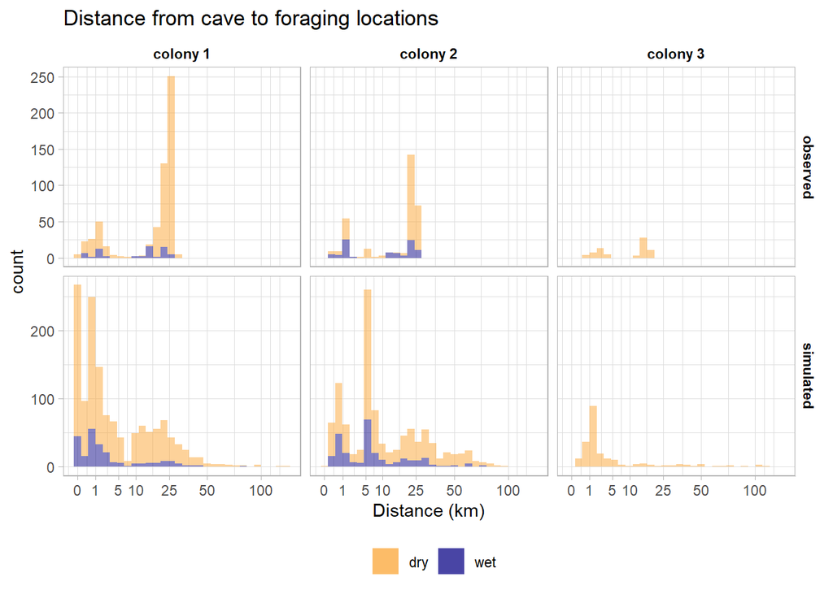

```r
ggplot() +
  theme_light() +
  labs(x='Distance (km)') +
  geom_histogram(data=foraging[foraging$type=='simulated',], aes(x=d2cave, fill=season), alpha=0.5) +
  geom_histogram(data=foraging[foraging$type=='observed',], aes(x=d2cave, fill=season), alpha=0.5) +
  scale_fill_viridis_d(end=0.8, option='C', name='', direction=-1) +
  facet_grid(type~factor(cave, levels=c('lagruta', 'ajcave', 'muddycave'), labels=paste('colony', 1:3)), scales='free_y') +
  scale_x_sqrt(breaks=c(0,1,5,10,25,50,100)) +
  theme(legend.position='bottom') +
  labs(title='Distance from cave to foraging locations') +
  theme(strip.background = element_rect(fill='white'), strip.text=element_text(colour='black', face='bold')) +
  guides(colour=guide_legend(override.aes = list(size=2, alpha=1)))
```

```r
# ggsave(filename='240717_distance_obs_vs_sim.png', width=200, height=120, unit='mm')
```

## Determine location of observed and simulated foraging locations

We will distinguish between Isla Colón, other islands in the erchipelago, and the mainland:

```r
p <- st_as_sf(foraging, coords=c('long', 'lat'), crs=st_crs(proj.ll))

colon <- st_as_sf(cave.loc[2,], coords=c('long', 'lat'), crs=st_crs(proj.ll))

mainland <- st_as_sf(st_cast(coastline, 'POLYGON'))
mainland$area <- st_area(mainland)
colon <- mainland[which(st_contains(mainland, colon, sparse=F)[,1]),]
mainland <- mainland[which.max(mainland$area),]

foraging$mainland <- st_within(p, mainland, sparse=F)[,1]
foraging$colon <- st_within(p, colon, sparse=F)[,1]
foraging$location <- ifelse(foraging$mainland, 'mainland',
                            ifelse(foraging$colon, 'isla colon', 'elsewhere'))
```

## Save simulated + observed foraging locations to file

```r
save(foraging, file='data/240502_foraging_all.RData')
```

**Note:** This file will be used as basis for the GLMMs which are detailed in Appendix X.